# Lectura y preparación de datos para Data Mining

# Descripción y enunciado

El objetivo de esta actividad es la gestión y preparación de datos. La gestión de datos es una parte muy importante de cualquier proceso de minería de datos, ya que los datos se deben preparar y preprocesar antes de iniciar el proceso de extracción de conocimiento. Esta tarea ilustra algunos de los procedimientos básicos con los que nos podemos encontrar para preparar los datos: analizar los tipos de datos, tranformar valores, detectar e eliminar outliers, hacer un muestreo, etcétera.

# Fichero de datos

El conjunto de datos con el que trabajaremos en esta actividad surge de la bases de datos disponibles en Kaggle . En concreto, los datos corresponden a los jugadores nombrados jugadores de la semana desde la temporada 1984-1985 hasta la temporada 2017-2018. Estos datos nos ofrecen múltiples posibilidades para consolidar los conocimientos y competencias de manipulación de datos, preprocesado y análisis descriptivo. El fichero `NBA_player_of_the_week.csv` se encuentra adjunto.

# Ingesta de datos

Actualmente el fichero se encuentra en la misma carpeta de datos RMD, está en adjunto. Se enviará nueva práctica similar con los datos de ingesta a través de scraping / API / base de datos para R y Python.

# Valoraciones

- se valorarán los trabajos por los detalles, no vale con el solo enviar un trozo de código, sino la explicación es fundamental
- explicar además los resumen de cada sección (carga, preparación, EDA, limpieza, nuevos atributos, discretización, split train-test)
- conclusiones y comparativas son los más importantes para comenzar con Data Mining.

Para resolver la actividad, deberéis usar algunos comandos de R que quizás no os resulten demasiado familiares y que recomendamos que investiguéis. Estos son:

- levels
- summary
- order/sort
- trimws
- sub
- table
- ifelse

## 1 Cargar un juego de datos

*Leer el fichero de datos “NBA_player_of_the_week.csv” y guardar los datos en un objeto con identificador denominado nba.* Cargamos el fichero csv a través de la función `read.csv` y establecemos el parámetro `stringsAsFactors` como False. Esto lo hacemos así ya que todas las variables no deben ser entendidas por defecto como factores, si no convertidas algunas de ellas más adelante si consideramos que es necesario y conveniente al realizar el análisis y la exploración de los datos. Por otra parte, establecemos el `header` como True para que tenga como encabezado los nombres que aparecen en la primera fila del csv.

```r
nba<-read.csv("NBA_player_of_the_week.csv", stringsAsFactors = FALSE, header = TRUE)
```

## 2 Descripción de los datos

*Describir brevemente la estructura de los datos: qué tipo de datos contiene, número de filas y columnas y nombre de las columnas. Realizar un resumen descriptivo de los datos.*

### tipo de dato con class()

```r
class(nba)
```

```
## [1] "data.frame"
```

### tipo de estructura

```r
str(nba)
```

```
## 'data.frame':    1145 obs. of  13 variables:
##  $ Age              : int  29 23 28 37 28 26 24 25 25 25 ...
##  $ Conference       : chr  "" "" "" "" ...
##  $ Date             : chr  "Apr 14, 1985" "Apr 7, 1985" "Apr 1, 1985" "Mar 24, 1985" ...
##  $ Draft.Year       : int  1978 1982 1979 1969 1978 1980 1982 1981 1979 1982 ...
##  $ Height           : chr  "6-5" "6-6" "6-6" "7-2" ...
##  $ Player           : chr  "Micheal Ray Richardson" "Derek Smith" "Calvin Natt" "Kareem Abdul-Jabbar" ...
##  $ Position         : chr  "PG" "SG" "F" "C" ...
##  $ Season           : chr  "1984-1985" "1984-1985" "1984-1985" "1984-1985" ...
##  $ Season.short     : int  1985 1985 1985 1985 1985 1985 1985 1985 1985 1985 ...
##  $ Seasons.in.league: int  6 2 5 15 5 4 2 3 5 2 ...
##  $ Team             : chr  "New Jersey Nets" "Los Angeles Clippers" "Denver Nuggets" "Los Angeles Lakers" ...
##  $ Weight           : chr  "189" "205" "220" "225" ...
##  $ Real_value       : num  1 1 1 1 1 1 1 1 1 1 ...
```

### head() es resumen de los 6 primeros resultados

```r
head(nba)
```

```
##   Age Conference         Date Draft.Year Height                 Player Position
## 1  29            Apr 14, 1985       1978    6-5 Micheal Ray Richardson       PG
## 2  23             Apr 7, 1985       1982    6-6            Derek Smith       SG
## 3  28             Apr 1, 1985       1979    6-6            Calvin Natt        F
## 4  37            Mar 24, 1985       1969    7-2    Kareem Abdul-Jabbar        C
## 5  28            Mar 17, 1985       1978    6-9             Larry Bird       SF
## 6  26            Mar 10, 1985       1980    6-4       Darrell Griffith       SG
##      Season Season.short Seasons.in.league                 Team Weight
## 1 1984-1985         1985                 6      New Jersey Nets    189
## 2 1984-1985         1985                 2 Los Angeles Clippers    205
## 3 1984-1985         1985                 5       Denver Nuggets    220
## 4 1984-1985         1985                15   Los Angeles Lakers    225
## 5 1984-1985         1985                 5       Boston Celtics    220
## 6 1984-1985         1985                 4            Utah Jazz    190
##   Real_value
## 1          1
## 2          1
## 3          1
## 4          1
## 5          1
## 6          1
```

### con ls() extraemos el listado de las variables (columnas)

```r
ls(nba)
```

```
##  [1] "Age"               "Conference"        "Date"
##  [4] "Draft.Year"        "Height"            "Player"
##  [7] "Position"          "Real_value"        "Season"
## [10] "Season.short"      "Seasons.in.league" "Team"
## [13] "Weight"
```

### usando names() también extraemos las etiquetas de las columnas

```r
names(nba)
```

```
##  [1] "Age"               "Conference"        "Date"
##  [4] "Draft.Year"        "Height"            "Player"
##  [7] "Position"          "Season"            "Season.short"
## [10] "Seasons.in.league" "Team"              "Weight"
## [13] "Real_value"
```

### extraemos las etiquetas de las filas con row.names() o rownames()

```r
row.names(nba)
```

```
##    [1] "1"    "2"    "3"    "4"    "5"    "6"    "7"    "8"    "9"    "10"
##   [11] "11"   "12"   "13"   "14"   "15"   "16"   "17"   "18"   "19"   "20"
##   [21] "21"   "22"   "23"   "24"   "25"   "26"   "27"   "28"   "29"   "30"
##   [31] "31"   "32"   "33"   "34"   "35"   "36"   "37"   "38"   "39"   "40"
##   [41] "41"   "42"   "43"   "44"   "45"   "46"   "47"   "48"   "49"   "50"
##   [51] "51"   "52"   "53"   "54"   "55"   "56"   "57"   "58"   "59"   "60"
##   [61] "61"   "62"   "63"   "64"   "65"   "66"   "67"   "68"   "69"   "70"
##   [71] "71"   "72"   "73"   "74"   "75"   "76"   "77"   "78"   "79"   "80"
##   [81] "81"   "82"   "83"   "84"   "85"   "86"   "87"   "88"   "89"   "90"
##   [91] "91"   "92"   "93"   "94"   "95"   "96"   "97"   "98"   "99"   "100"
##  [101] "101"  "102"  "103"  "104"  "105"  "106"  "107"  "108"  "109"  "110"
##  [111] "111"  "112"  "113"  "114"  "115"  "116"  "117"  "118"  "119"  "120"
##  [121] "121"  "122"  "123"  "124"  "125"  "126"  "127"  "128"  "129"  "130"
##  [131] "131"  "132"  "133"  "134"  "135"  "136"  "137"  "138"  "139"  "140"
##  [141] "141"  "142"  "143"  "144"  "145"  "146"  "147"  "148"  "149"  "150"
```

[output cut: 100 more lines]

# 3.Preparación de la base de datos

## 3.1 Asignar NA a los valores ausentes en los datos de Conference.

Para asignar los NAs a los valores ausentes en los datos del atributo `Conference`, en primer lugar miramos los niveles que tiene dicho atributo a través de la función `levels`, en este caso vemos que el resultado es “NULL”, ya que al no ser una variable factorial si no de tipo “character” no tiene niveles (esto lo comprobamos usando la función `typeof`).

```r
# Comprobamos los valores del atributo `Conference`.
levels(nba$Conference)
```

[output not shown]

```r
# Comprobamos el tipo de variable que es el atributo `Conference`.
typeof(nba$Conference)
```

```
## [1] "character"
```

*creamos una lista conf*

```r
conf <- (nba$Conference)
```

```r
conf
```

```
##    [1] ""     ""     ""     ""     ""     ""     ""     ""     ""     ""
##   [11] ""     ""     ""     ""     ""     ""     ""     ""     ""     ""
##   [21] ""     ""     ""     ""     ""     ""     ""     ""     ""     ""
##   [31] ""     ""     ""     ""     ""     ""     ""     ""     ""     ""
##   [41] ""     ""     ""     ""     ""     ""     ""     ""     ""     ""
##   [51] ""     ""     ""     ""     ""     ""     ""     ""     ""     ""
##   [61] ""     ""     ""     ""     ""     ""     ""     ""     ""     ""
##   [71] ""     ""     ""     ""     ""     ""     ""     ""     ""     ""
##   [81] ""     ""     ""     ""     ""     ""     ""     ""     ""     ""
##   [91] ""     ""     ""     ""     ""     ""     ""     ""     ""     ""
##  [101] ""     ""     ""     ""     ""     ""     ""     ""     ""     ""
##  [111] ""     ""     ""     ""     ""     ""     ""     ""     ""     ""
##  [121] ""     ""     ""     ""     ""     ""     ""     ""     ""     ""
##  [131] ""     ""     ""     ""     ""     ""     ""     ""     ""     ""
##  [141] ""     ""     ""     ""     ""     ""     ""     ""     ""     ""
```

[output cut: 100 more lines]

*Asignar NA a los valores ausentes en los datos de Conference.*

```r
conf[conf == ""] <- NA
```

*comprobaremos los nuevos datos asignados*

```r
str(conf)
```

```
##  chr [1:1145] NA NA NA NA NA NA NA NA NA NA NA NA NA NA NA NA NA NA NA NA ...
```

## 3.2 Transformar los datos de Conference en variable categórica y mostrar la tabla de frecuencia.

Para realizar la factorización del atributo “Conference” utilizamos la función `as.factor`. Posteriormente, comprobamos los niveles de nuestra variable categórica y mostramos la tabla de frecuencias absolutas y relativas para ver la distribución de los niveles en la variable.

```r
# Realizamos la factorización del atributo.
conf <- as.factor(conf)

# Comprobamos los niveles.
levels(conf)
```

```
## [1] "East" "West"
```

```r
# Mostramos la tabla de frecuencias absolutas.
table(conf)
```

```
## conf
## East West
##  381  380
```

```r
# Mostramos la tabla de frecuencias relativas redondeando con dos decimales.
round(prop.table(table(conf)), 2)
```

```
## conf
## East West
##  0.5  0.5
```

Para comprobar los valores ausentes, utilizaremos la función `ìs.na` junto a la función `sum` y obtendremos de esta forma la suma de todos los NAs existentes en la variable “conf”.

```r
# Sumamos todos los NAs en la variable conf.
sum(is.na(conf))
```

```
## [1] 384
```

## 3.4 Transformar las variables Height, Player, Position, Season, Team y Weight en variables categóricas.

Para la factorización de los atributos utilizaremos nuevamente la función `as.factor`.

```r
# Realizamos la factorización de los atributos.
nba$Height <- as.factor(nba$Height)
nba$Player <- as.factor(nba$Player)
nba$Position <- as.factor(nba$Position)
nba$Season <- as.factor(nba$Season)
nba$Team <- as.factor(nba$Team)
nba$Weight <- as.factor(nba$Weight)
```

## 3.5 Comprobar que estas variables no tienen valores perdidos.

Para comprobar que no existen valores perdidos sumaremos todos los NAs existentes en cada una de las columnas con la función `is.na` y `sum`. En este caso, verificamos que ningún atributo tiene valores perdidos.

```r
# Sumamos todos los NAs existentes en cada una de las columnas.
sum(is.na(nba$Height))
```

```
## [1] 0
```

```r
sum(is.na(nba$Player))
```

```
## [1] 0
```

```r
sum(is.na(nba$Position))
```

```
## [1] 0
```

```r
sum(is.na(nba$Season))
```

```
## [1] 0
```

```r
sum(is.na(nba$Team))
```

```
## [1] 0
```

```r
sum(is.na(nba$Weight))
```

```
## [1] 0
```

## 3.6 Calcular el número de anyos que pasan entre que salio el jugador elegido en el draft y la temporada en la que fue jugador de la semana. Denomina la variable tiempo.

Para calcular el número de años que transcurren entre que salió el jugador elegido en el draft y la temporada en la que fué jugador de la semana, le restamos a la columna `Season.short` la columna `Draft.Year` y guardamos el resultado en una nueva variable a la que llamaremos `time`. Usamos la función `head` para mostrar los primeros resultados de la nueva variable.

```r
# Operamos entre columnas y guardamos el resultado en una nueva variable.
time = nba$Season.short - nba$Draft.Year

# Motramos los primeros resultados de la nueva variable para comprobar que se ha creado correctamente.
head(time)
```

```
## [1]  7  3  6 16  7  5
```

## 3.7 ¿Cual es el número de años que más veces se repite entre que salen elegidos en el draft y se proclaman mejores jugadores? (moda de la variable tiempo)

Para conocer el valor que nos pide el ejercicio calcularemos la tabla de frecuencia del atributo `time`, visualizando tanto sus valores absolutos como sus valores relativos, esto nos permitirá conocer con exactitud cuál es su moda. Comprobamos que el atributo `time` tiene una moda con valor de 7, que representa una frecuencia del 12%.

```r
# Tabla de frecuencias de valores absolutos.
table(time)
```

```
## time
##   1   2   3   4   5   6   7   8   9  10  11  12  13  14  15  16  17  18  19
##  21  50  93 118 133 140 141 115  96  79  47  37  32  17   9   6   7   2   2
```

```r
# Tabla de frecuencias de valores relativos redondeando con dos decimales.
round(prop.table(table(time)), 2)
```

```
## time
##    1    2    3    4    5    6    7    8    9   10   11   12   13   14   15   16
## 0.02 0.04 0.08 0.10 0.12 0.12 0.12 0.10 0.08 0.07 0.04 0.03 0.03 0.01 0.01 0.01
##   17   18   19
## 0.01 0.00 0.00
```

## 3.8 La altura de los jugadores está expresada en pies (aquellas con guión) y cm. Convertir la altura expresada en pies a centimetros https://www.piesametros.info/. Posteriormente, eliminar el texto “cm” de los datos de tipo altura y convertir la variable en numérica. Calcular media, desviación típica y boxplot.

Para poder convertir la altura en pies a centímetros, en primer lugar convertiremos la variable “Height” en una variable de tipo character, ya que siendo una variable categórica no podríamos procesarla con funciones que utilizaremos como `strsplit`.

```r
# Convertimos el atributo `Height` en character.
nba$Height <- as.character(nba$Height)

# Calculamos el número de filas.
filas = nrow(nba)

# Creamos las variables de conversión.
inches_in_a_feet = 12
cm_in_a_inch = 2.54

# Iteramos sobre la columna altura a lo largo de todas sus filas.
for (altura in 1:filas){
  # Utilizamos la función `grepl` que nos devolverá True si la cadena de la altura contiene un guión.
  if (grepl("-", nba$Height[altura])){

    # Aplicamos la conversión de pies y pulgadas a centímetros.
    # Utilizamos `strsplit` para obtener por separado los pies y las pulgadas.
    part_heitght <- strsplit(nba$Height[altura],"-")[[1]]
    # En la variable part_height tenemos un vector con dos cadenas, la primera contiene los pies
    # y la segunda las pulgadas. Utilizamos as.numeric para convertirlas a valores numéricos y
    # multiplicamos por las variables de conversión para obtener el valor en cm.
    feet <- as.numeric(part_heitght[1]) * inches_in_a_feet * cm_in_a_inch
    inch <- as.numeric(part_heitght[2]) * cm_in_a_inch
    # Por último, sumamos ambos valores previamente transformados a cm para obtener la altura total y
    # guardamos el resultado de nuevo en la columna altura.
    nba$Height[altura] = feet + inch
  }

  # Si el valor de altura no contiene un guión pero sí contiene la cadena "cm" tenemos que eliminarla
  # para quedarnos solo con el valor numérico.
  else if (grepl("cm", nba$Height[altura])){
    nba$Height[altura] =  sub("cm", "", nba$Height[altura])
  }
}

# Convertimos el atributo `Height` en numérico.
nba$Height <- as.numeric(nba$Height)

# Comprobamos el tipo.
typeof(nba$Height)
```

```
## [1] "double"
```

```r
# Comprobamos que no se han introducido valores NAs.
sum(is.na(nba$Height))
```

```
## [1] 0
```

Calculamos la media, la desviación típica y visualizamos un gráfico boxplot de la columna “Height”. Utilizamos para ello las funciones `mean`, `sd` y `boxplot`.

```r
# Calculamos la media.
mean(nba$Height)
```

```
## [1] 201.0231
```

```r
# Calculamos la desviación típica.
sd(nba$Height)
```

```
## [1] 9.410947
```

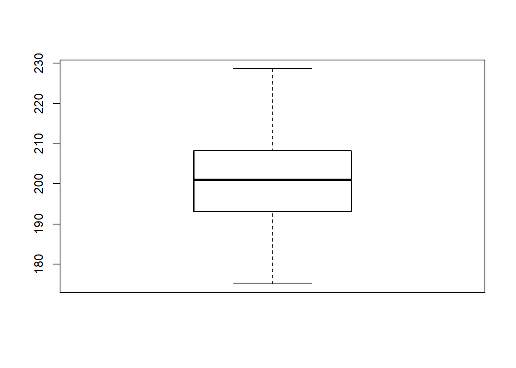

```r
# Visualizamos con un gráfico boxplot.
boxplot(nba$Height)
```

### 3.9

El peso de los jugadores está expresada en libras y kg. Convertir el peso expresado en kgs en libras https://www.metric-conversions.org/es/peso/kilogramos-a-libras.htm. Convertir la variable en numérica.Calcular media, desviación típica y boxplot. Al igual que en el ejercicio anterior, transformamos el atributo “Weight” a tipo character con la función `as.character` y se realiza la transformación de kilos a libras de forma análoga.

```r
# Convertimos el atributo `Weight` en character.
nba$Weight <- as.character(nba$Weight)

# Creamos la variable con el valor de la equivalencia de un kg.
one_kg_in_lb = 2.204623

# Iteramos sobre el total de filas.
for (weight in 1:filas){

  # Si el peso contiene la cadena "kg", la eliminamos, convertimos el valor a numérico y aplicamos la
  # conversión.
  if (grepl("kg",nba$Weight[weight])){
    nba$Weight[weight] = as.numeric(sub("kg", "", nba$Weight[weight])) * one_kg_in_lb
  }
}

# Convertimos el atributo `Weight` en numérico.
nba$Weight <- as.numeric(nba$Weight)

# Comprobamos el tipo.
typeof(nba$Weight)
```

```
## [1] "double"
```

```r
# Comprobamos que no se han introducido valores NAs.
sum(is.na(nba$Weight))
```

```
## [1] 0
```

Calculamos la media, la desviación típica y visualizamos un gráfico boxplot de la columna “Weight”. Utilizamos para ello las funciones `mean`, `sd` y `boxplot`.

```r
# Calculamos la media.
mean(nba$Weight)
```

```
## [1] 226.0039
```

```r
# Calculamos la desviación típica.
sd(nba$Weight)
```

```
## [1] 31.57769
```

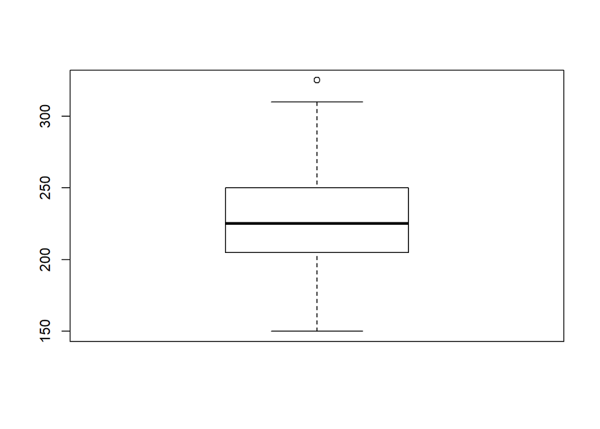

```r
# Visualizamos con un gráfico boxplot.
boxplot(nba$Weight)
```

# 4 Información sobre posiciones en el campo y equipos.

## 4.1 Fusionar las categorias de posición en el campo F,F-C y FC en la categoría genérica Forward. Fusionar las categorias G,G-F y GF en la categoria genérica Guard. Renombrar la categoría ‘PG’ como ‘Point Guard’, ‘SG’ como ‘Shooting Guard’, ‘SF’ como ‘Small Forward’, ‘PF’ como ‘Power Forward’ y ‘C’ como ‘Center’.

```r
# Al igual que en los casos anteriores, convertimos el atributo `Position` en character.
nba$Position <- as.character(nba$Position)

# Creamos dos vectores con los valores que corresponden a las categorías "Forward" y "Guard"
# respectivamente.
Forward <- c("F", "F-C", "FC")
Guard <- c("G", "G-F", "GF")

# Iteramos sobre el total de filas.
for (i in 1:filas){

  # Comprobamos si el valor de "Position" es alguno de los que se corresponden con las nuevas
  # categorías y reasignamos el valor.
  if (nba$Position[i] %in% Forward){
    nba$Position[i] = "Forward"
  }
  else if (nba$Position[i] %in% Guard){
    nba$Position[i] = "Guard"
  }
  # En caso de no ser de las nuevas categorías, comprobamos los valores individuales para
  # asignarles su nuevo nombre.
  else if (nba$Position[i] == "PG"){
    nba$Position[i] = "Point Guard"
  }
  else if (nba$Position[i] == "SG"){
    nba$Position[i] = "Shooting Guard"
  }
  else if (nba$Position[i] == "SF"){
    nba$Position[i] = "Small Forward"
  }
  else if (nba$Position[i] == "PF"){
    nba$Position[i] = "Power Forward"
  }
  else if (nba$Position[i] == "C"){
    nba$Position[i] = "Center"
  }
}
```

## 4.2 ¿En que posición ha sido más veces los jugadores de la semana nombrados?

Los jugadores de la semana han sido nombrados más veces en la posición `Guard`, con una frecuencia relativa de 0.20.

```r
# Tabla de frecuencias de valores absolutos.
table(nba$Position)
```

```
##
##         Center        Forward          Guard    Point Guard  Power Forward
##            158            217            228            120            139
## Shooting Guard  Small Forward
##            164            119
```

```r
# Tabla de frecuencias de valores relativos redondeando con dos decimales.
round(prop.table(table(nba$Position)), 2)
```

```
##
##         Center        Forward          Guard    Point Guard  Power Forward
##           0.14           0.19           0.20           0.10           0.12
## Shooting Guard  Small Forward
##           0.14           0.10
```

## 4.3 ¿Cuántos equipos distintos hay?

Hay Treinta y cinco equipos diferentes.

```r
# Comprobamos los NAs para que en el caso de haberlos no considerarlos como un equipo más.
sum(is.na(nba$Team))
```

```
## [1] 0
```

```r
# Calculamos los valores únicos.
unique(nba$Team)
```

```
##  [1] New Jersey Nets        Los Angeles Clippers   Denver Nuggets
##  [4] Los Angeles Lakers     Boston Celtics         Utah Jazz
##  [7] Golden State Warriors  Dallas Mavericks       Atlanta Hawks
## [10] Washington Bullets     Chicago Bulls          Cleveland Cavaliers
## [13] Detroit Pistons        Milwaukee Bucks        Seattle SuperSonics
## [16] New York Knicks        Philadelphia Sixers    Phoenix Suns
## [19] Indiana Pacers         Portland Trail Blazers San Antonio Spurs
## [22] Sacramento Kings       Houston Rockets        Miami Heat
## [25] Orlando Magic          Charlotte Hornets      Minnesota Timberwolves
## [28] Toronto Raptors        Washington Wizards     New Orleans Hornets
## [31] Memphis Grizzlies      Charlotte Bobcats      Oklahoma City Thunder
## [34] Brooklyn Nets          New Orleans Pelicans
## 35 Levels: Atlanta Hawks Boston Celtics Brooklyn Nets ... Washington Wizards
```

## 4.4 ¿Cuáles son los cinco equipos que más veces han sido nombrados sus jugadores como jugador de la semana?

Para calcular los equipos que más aparecen utilizaremos la functión `table` para obtener las frecuencias, ordenaremos el resultado y nos quedaremos con los cinco valores más altos.

```r
# Ordenamos las frecuencias de "Team" utilizando "decreasing = TRUE" para que la ordenación
# sea de mayor a menor.
list_teams_sorted <- sort(table(nba$Team), decreasing = TRUE)

# Seleccionamos los cinco primeros equipos y los mostramos por pantalla.
list_teams_sorted[1:5]
```

```
##
##  Los Angeles Lakers   San Antonio Spurs Cleveland Cavaliers          Miami Heat
##                  71                  61                  59                  57
##     Houston Rockets
##                  56
```

```r
# Otra forma de ordenar los datos es con la función `order`, que devuelve un array con los índices ordenados.
order(table(nba$Team))
```

```
##  [1]  3 22 34 16  4 21  5 31 13 29 35 18 19 14 10  8 20 32  1 28 23 26  9 24  2
## [26]  6 11 25 27 33 12 17  7 30 15
```

# 5 Información sobre jugadores. Estadísticos descriptivos.

## 5.1 Crear una base datos denominada nba.unique en la que no se repita el nombre de ningún jugador.Trabajar a partir de ahora con esta base de datos.

Para identificar los nombres duplicados utilizaremos la función `duplicated`, que nos devuelve un vector con booleanos indicando qué filas están duplicadas.

```r
# Comprobamos cuántos valores únicos hay en la columna "Player".
length(unique(nba$Player))
```

```
## [1] 274
```

```r
# Utilizamos la función `duplicated` para crear el nuevo dataframe sin los jugadores repetidos.
nba.unique <- nba[!duplicated(nba$Player), ]

# Comprobamos que el número de filas del nuevo dataframe coincide con los valores únicos de
# la columna "Player" calculados anteriormente.
nrow(nba.unique)
```

```
## [1] 274
```

## 5.2 Listar el nombre de los 10 jugadores más bajos que han sido nombrados alguna vez jugadores de la semana. No debe repetirse ningún nombre.

Para obtener el listado de los jugadores más bajos, usaremos la función `order` para obtener un listado de índices ordenados y quedarnos los diez menores. Con estos índices filtraremos el dataframe y mostraremos las columnas “Player” y “Height”.

```r
# Los ordenamos con la función `order` y seleccionamos los diez primeros.
smallest_players_index <- order(nba.unique$Height)[1:10]

# Mostramos por pantalla la variable.
smallest_players_index
```

```
##  [1] 227 245  51 104 220  54  85  97 105 115
```

```r
# Seleccionamos los diez jugadores más bajos y los mostramos por pantalla.
nba.unique[smallest_players_index, c("Player", "Height")]
```

```
##                Player Height
## 894     Nate Robinson 175.26
## 968     Isaiah Thomas 175.26
## 111     Michael Adams 177.80
## 274   Terrell Brandon 180.34
## 859         Ty Lawson 180.34
## 126      Tim Hardaway 182.88
## 220    Kenny Anderson 182.88
## 252      Elliot Perry 182.88
## 279     Allen Iverson 182.88
## 330 Darrell Armstrong 182.88
```

## 5.3 Listar el nombre de los 10 jugadores más altos que han sido nombrados y mostrar su altura. No debe repetirse ningún nombre.

Para obtener los jugadores más altos utilizaremos el procedimiento del ejercicio anterior, usando la función `order` para obtener un listado de índices ordeado.

```r
# Los ordenamos con la función `order`, ajustando el parámetro decresing para que los ordene de mayor
# a menor. Seleccionamos los diez primeros.
tallest_players_index <- order(nba.unique$Height, decreasing = TRUE)[1:10]

# Mostramos por pantalla la variable.
tallest_players_index
```

```
##  [1] 155  91 274  99 153   4  79  52  84  89
```

```r
# Seleccionamos los diez jugadores más altos y los mostramos por pantalla.
nba.unique[tallest_players_index, c("Player", "Height")]
```

```
##                   Player Height
## 487             Yao Ming 228.60
## 237            Rik Smits 223.52
## 1140  Kristaps Porzingis 221.00
## 257      Arvydas Sabonis 220.98
## 484   Zydrunas Ilgauskas 220.98
## 4    Kareem Abdul-Jabbar 218.44
## 189      Dikembe Mutombo 218.44
## 116       David Robinson 215.90
## 207     Shaquille O'Neal 215.90
## 235          Vlade Divac 215.90
```

# 6 Eliminación de outliers.

## 6.1 Eliminar los outliers de la variable peso (Weight) y guardar en un data frame nba.avg

Para ratificar que los outliers han sido correctamente eliminados, visualizaremos el gráfico boxplot a través de la función `boxplot` antes y después de eliminarlos. Exponemos dos métodos posibles para el cálculo de outliers.

```r
# Cálculo de outliers.

# Método uno.
# Definimos los valores outliers como los que están por encima de la media tres desviaciones típicas.
outlier_ran_low <- mean(nba.unique$Weight) - 3 * sd(nba.unique$Weight)
outlier_ran_up <- mean(nba.unique$Weight) + 3 * sd(nba.unique$Weight)

# Buscamos los outliers en la variable "Weight".
outlier_low <- nba.unique$Weight[which(nba.unique$Weight < outlier_ran_low)]
outlier_up <- nba.unique$Weight[which(nba.unique$Weight > outlier_ran_up)]

# Mostramos los valores outliers.
outlier_low
```

```
## numeric(0)
```

```r
outlier_up
```

```
## [1] 325 310
```

```r
# Método dos.
# Utilizamos la función `boxplot` con el parámetro plot = False que nos devuelve una lista con la
# información del gráfico. Seleccionamos la columna `out` que contiene los valores de los outliers.
outliers <- boxplot(nba.unique$Weight, plot=FALSE)$out

# Mostramos los valores outliers (que coinciden con los calculados manualmente).
outliers
```

```
## [1] 325 310
```

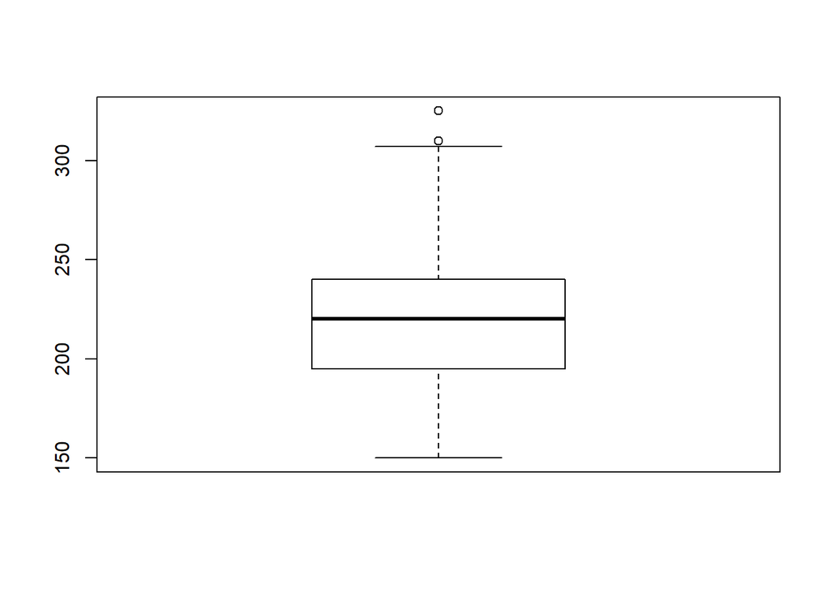

```r
# Visualizamos el boxplot del dataframe nba.unique.
boxplot(nba.unique$Weight)
```

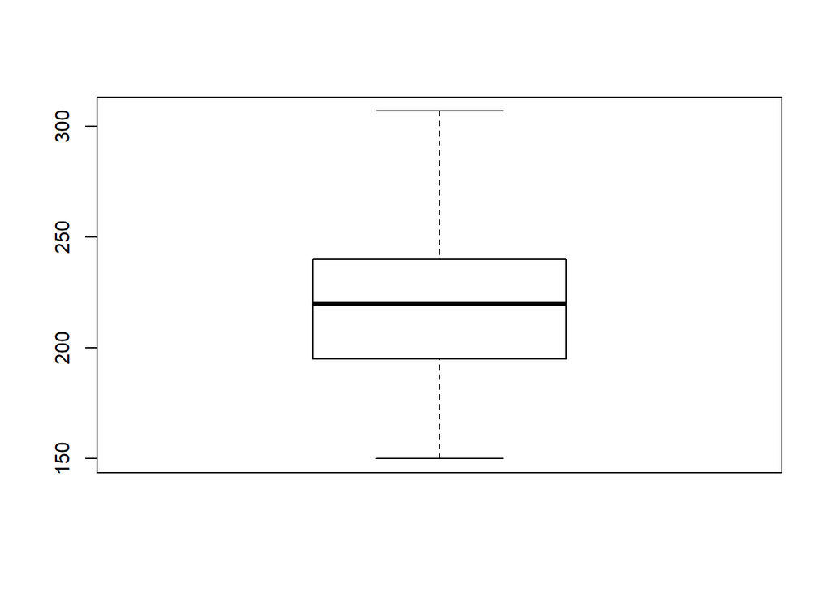

```r
# Guardamos el resultado en un nuevo dataframe sin outliers utilizando la función `which`.
nba.avg <- nba.unique[-which(nba.unique$Weight %in% outliers), ]

# Visualizamos el boxplot del dataframe nba.avg.
boxplot(nba.avg$Weight)
```

## 6.2 Comparar los boxplots de los datos originales en nba.unique y de los datos del peso de nba.avg

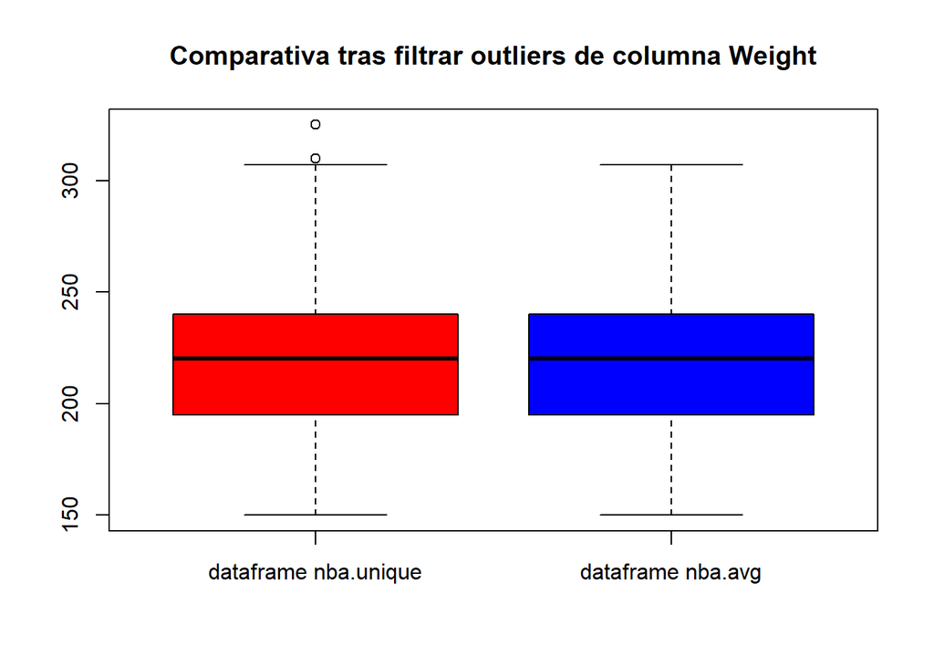

```r
# Visualizamos la comparativa personalizando el gráfico.
boxplot(nba.unique$Weight, nba.avg$Weight,
        names = c("dataframe nba.unique","dataframe nba.avg"),
        col = c("Red", "Blue"),
        main = "Comparativa tras filtrar outliers de columna Weight"
        )
```

## 6.3 Interpretar los resultados

Si comparamos el resumen estadístico de los datos que nos devuelve la función `summary` antes y después de la eliminación de los outliers en la columna “Weight”, podemos comprobar que se han producido cambios en los datos del dataframe. El número de elementos se ha reducido de 274 a 272, ya que existían dos outliers, y esto ha provocado cambios en el resto de estadísticos del atributo como los presentados a continuación:

- La media ha pasado de tener un valor de 219,1 a 218,4.
- Y por su parte el valor máximo ha pasado de ser 325 a 307.

Por otro lado, otros estadísticos se han mantenido igual, como es el caso de la mediana, con un valor de 220, el mínimo (con un valor de 150), y el quartil 1º y 3º, con valores de 195 y 240, respectivamente.

```r
# Resumen estadístico de nba.unique a través de la función `summary`.
summary(nba.unique$Weight)
```

```
##    Min. 1st Qu.  Median    Mean 3rd Qu.    Max.
##   150.0   195.0   220.0   219.1   240.0   325.0
```

```r
# Comprobar número de elementos con la función `nrows`.
nrow(nba.unique)
```

```
## [1] 274
```

```r
# Resumen estadístico del nuevo dataframe "nba.avg" con la función `summary`.
summary(nba.avg$Weight)
```

```
##    Min. 1st Qu.  Median    Mean 3rd Qu.    Max.
##   150.0   195.0   220.0   218.4   240.0   307.0
```

```r
# Comprobar número de elementos con la función `nrows`.
nrow(nba.avg)
```

```
## [1] 272
```

# 7 Clasificación de jugadores

## 7.1 Añadir una columna al conjunto de datos denominada “Altura” que contenga los valores: {“bajo”, “normal”, “alto”}. La asignación del valor depende de la altura de cada jugador. Se asigna:

- bajo: los 50 jugadores más bajos
- alto: los 50 jugadores más altos
- normal: el resto de jugadores

```r
# Creamos una nueva columna con el nombre "Altura" y asignamos por defecto todos los valores como
# "normal".
nba.avg$Altura <- "normal"

# Creamos las condiciones de "alto" y "bajo" con la función `order`.
tallest_height_index <- order(nba.avg$Height, decreasing = TRUE)[1:50]
smallest_height_index <- order(nba.avg$Height)[1:50]

# Asignamos las condiciones a la nueva columna.
nba.avg$Altura[tallest_height_index] <- "alto"
nba.avg$Altura[smallest_height_index] <- "bajo"

# Factorizamos el atributo `Altura` ya que hemos convertido sus valores en categóricas.
nba.avg$Altura <- as.factor(nba.avg$Altura)
```

## 7.2 Añadir una columna al conjunto de datos denominada “Peso” que contenga los valores: {“bajo”, “normal”, “alto”}. La asignación del valor depende del peso de cada jugador. Se asigna:

- bajo: los 50 jugadores con menor peso
- alto: los 50 jugadores con mayor peso
- normal: el resto de jugadores

```r
# Creamos una nueva columna con el nombre "Peso" y asignamos por defecto todos los valores como "normal".
nba.avg$Peso <- "normal"

# Creamos las condiciones de "alto" y "bajo" con la función `order`.
heaviest_weight_index <- order(nba.avg$Weight, decreasing = TRUE)[1:50]
lowest_weight_index <- order(nba.avg$Weight)[1:50]

# Asignamos las condiciones a la nueva columna.
nba.avg$Peso[heaviest_weight_index] <- "alto"
nba.avg$Peso[lowest_weight_index] <- "bajo"

# Factorizamos el atributo `Peso` ya que hemos convertido sus valores en categóricas.
nba.avg$Peso <- as.factor(nba.avg$Peso)
```

## 7.3 Calcular la media y desviación típica del peso (Weight) según la clasificación de altura de los jugadores.

```r
# Importamos la librería `dplyr`.
library(dplyr)
# Calculamos la media y la desviación típica del atributo `Weight` según la nueva columna a través de
# las funciones `group_by` y `summarise`.
group_by(nba.avg,nba.avg$Altura) %>% summarise(
  mean_weight = mean(Weight),
  sd_weight = sd(Weight)
)
```

```
## # A tibble: 3 x 3
##   `nba.avg$Altura` mean_weight sd_weight
##   <fct>                  <dbl>     <dbl>
## 1 alto                    247.      19.8
## 2 bajo                    183.      12.3
## 3 normal                  220.      22.2
```

## 7.4 Realizar un boxplot del peso (Weight) según la clasificación de altura del jugador. Los boxplots deben estar ordenados de menos a mayor altura.

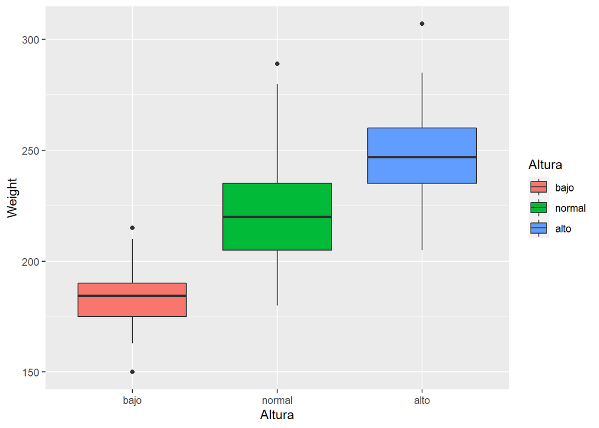

```r
# Importamos la librería `ggplot2`.
library(ggplot2)

# Ordenamos el factor `Altura` para que al visualizar el resultado en el boxplot quede ordenado.
# Usamos la función `factor` en lugar de `as.factor` para poder reasignar los niveles.
nba.avg$Altura <- factor(nba.avg$Altura, levels = c("bajo", "normal", "alto"))

# Visualizamos el peso según la clasificación de altura del jugador.
ggplot(nba.avg, aes(x = Altura, y = Weight, fill = Altura)) +
    geom_boxplot()
```

## 7.5 Hacer un listado con el nombre de jugadores que tienen una altura ‘normal’ y un peso ‘alto’. Ordenar alfabéticamente por nombre.

```r
# Usamos la función `which`.
list_players_two <- nba.avg[which(nba.avg$Altura == "normal" & nba.avg$Peso == "alto"), ]

# Obtenemos los índices ordenados por nombre y lo guardamos en una variable.
list_names_index <- order(list_players_two$Player)

# Ordenamos alfabéticamente nuestro nuevo dataframe utilizando la variable anteriormente creada.
list_players_two[list_names_index, ]
```

```
##      Age Conference         Date Draft.Year Height            Player
## 626   22       East  Mar 4, 2007       2004 208.28      Al Jefferson
## 977   21       West Mar 16, 2015       2012 208.28     Anthony Davis
## 451   26       East Jan 19, 2003       1996 205.74    Antoine Walker
## 911   23       West Dec 10, 2012       2009 208.28     Blake Griffin
## 496   22       East Jan 25, 2004       2002 205.74     Carlos Boozer
## 26    23            Mar 30, 1986       1984 198.12   Charles Barkley
## 222   20             Jan 9, 1994       1993 205.74      Chris Webber
## 719   28       West  Mar 2, 2009       2003 205.74        David West
## 854   30       East Mar 19, 2012       2002 208.28       Drew Gooden
## 418   22       West  Dec 9, 2001       1999 205.74       Elton Brand
## 249   22            Dec 11, 1994       1993 203.20    Jamal Mashburn
## 938   21       East Feb 10, 2014       2012 205.74   Jared Sullinger
## 52    23            Mar 15, 1987       1985 205.74       Karl Malone
## 937   25       West Feb 24, 2014       2008 208.28        Kevin Love
```

[output cut: 57 more lines]

# 8 Preparación de datos para la minería de datos

```r
#install.packages(caTools)
require(caTools) # para el train-test utilizamos la libreia(caTools)
```

## 8.5 Escribir los conjuntos de train y test en un fichero.

```r
#write.csv(train, "train70.csv", row.names=FALSE)
#write.csv(test, "test30.csv", row.names=FALSE)
```